# Final Project- Mobility During Covid

Chandra Bhushan Gupta, 16:954:597:01 DATA WRANGLING

#### Project Description

Within months, COVID-19 went from an epidemic to a pandemic. From the first identified case in December 2019 and wide impact visibly considered from March especially in US - there were many precautions and government orders put in place. People and communities have responded differently to such changes/developments especially mobility and transportation. Whilst we are well aware of the widespread usage of the analytics produced by various COVID data, merging the data with other sources might provide more insight around the efforts being put in flattening the curve. My effort will be to unify the data and source them to put forward summary and stats to get better insights and perspective around all the initiatives - How mobility, stay at home, movement restrictions were perceived. Supplement this data with visualizations to explain the effectiveness around all the efforts. Aim is to get deeper into insights by collating data from various sources, clean them up and perform analysis.

#### Data

In my project, following are the main sources of data

- *Google Mobility Data* - Data was downloaded from Google in the form of CSV. CSV is available for 2020 and 2021 in different CSV files.

#### Data Definition(Original)

| Google Sheet element | Definition |
| --- | --- |
| sub_region_1 | US State Name |
| retail_and_recreation_percent_change_from_baseline | Retail and Recreation Mobility |
| grocery_and_pharmacy_percent_change_from_baseline | Grocery and Pharmacy Mobility |
| parks_percent_change_from_baseline | Parks Mobility |
| transit_stations_percent_change_from_baseline | Transit Mobility |
| workplaces_percent_change_from_baseline | Workplace Mobility |
| residential_percent_change_from_baseline | Residential address Mobility |
| date | date of an event |

Reference https://www.google.com/covid19/mobility/

- *Apple Mobility Data* - Apple mobility Data

| Apple Sheet element | Definition |
| --- | --- |
| region | US State Name |
| transportation_type | driving" “walking”, “transit” |
| X“YYYY.MM.DD” | Date as a header |

Reference https://covid19.apple.com/mobility

- *Covid Now Data* - With the help of API key, data was retrieved from Covid Act. It is an independent 501(c)(3) nonprofit founded by volunteers in March 2020.

| API Field | Definition |
| --- | --- |
| actuals.cases | Cumulative confirmed or suspected cases |
| metrics.caseDensity | # of cases per 100k population calculated using a 7-day rolling average |
| metrics.infectionRate | R_t, or the estimated number of infections arising from a typical case. |
| actuals.deaths | Cumulative deaths that are suspected or confirmed . |
| actuals.newCases | New confirmed or suspected cases |
| metrics.infectionRate | R_t, or the estimated number of infections arising from a typical case. |

- *BTS (Bureau of Transportation)* Data has been pull with the help of API token from JSON end point from Bureau of Transportation and Statistics. Packcage RSocrata is being used to download the data

| API Field | Definition |
| --- | --- |
| State.Postal.Code | State Code |
| pop_stay_at_home | Population who stayed Home , persons who make no trips with a trip end more than one mile away from home |
| pop_not_stay_at_home | Population not staying at home |
| trips | Total Number of Trips made on a day |
| date | Date |

Reference - https://dev.socrata.com/foundry/data.bts.gov/w96p-f2qv

- *Covid Govt Response Tracker* Governments are taking a wide range of measures in response to the COVID-19 outbreak. This data aims to track and compare policy responses around the world.

| API Field | Definition |
| --- | --- |
| RegionName | Us State Name |
| Date | Date of occurance |
| ContainmentHealthIndex | combines ‘lockdown’ restrictions and closures with measures such as testing policy and contact tracing |
| GovernmentResponseIndex | how the response of governments has varied over all indicators in the database, becoming stronger or weaker over the course of the outbreak) |
| StringencyIndex | the strictness of ‘lockdown style’ policies that primarily restrict people’s behaviour |

Reference - https://www.bsg.ox.ac.uk/research/research-projects/covid-19-government-response-tracker

### Packages used in the Project

```r
library(tidyverse)  # all tidyverse packages
library(tidyr) # Supports tidyverse package
library(purrr) # Complements tidyverse
library(stringr) # Supports any  string operations
library(choroplethr) # package for Choropleths  thematic maps
library(choroplethrMaps) # Contains Maps Used by the 'choroplethr' Package
library(countrycode) # For country code mapping
library(tidycensus) # To get Census data that is pre-prepared for exploration within the tidyverse
library(lubridate) # Date handling package
library(usdata) # used to handle state codes and many others
library(ggplot2) # Standard ggpplot graph
library(gridExtra) # To arrange Graph in a Grid
library(zoo) # moving averages
library("RSocrata") #To donwload API Data
library(hrbrthemes)
```

### Data Wrangling

#### Function

```r
#### Function to clean up Google sheet data
google_mobility_func <- function(df){
  mobility_data_frame <- df %>%
    filter(sub_region_1 !="") %>%
    filter(is.na(census_fips_code) | census_fips_code == 11001) %>%
    select (date,sub_region_1,ends_with("_baseline")) %>%
    mutate(event_date= as.Date(date, format = "%Y-%m-%d")) %>%
    rename(Province_State=sub_region_1) %>%
    select(-date)
}
```

```r
##### Get Google Data and Combine them in one sheet
google_mobility_us_2021 <- google_mobility_func(read.csv("data/2021_US_Region_Mobility_Report.csv"))
google_mobility_us_2020 <-  google_mobility_func(read.csv("data/2020_US_Region_Mobility_Report.csv"))
google_mobility_us_states  <- rbind(google_mobility_us_2021,  google_mobility_us_2020)
```

#### Apple data set cleaning

Apple mobility data * Filter the United States * Select the Transportation Type * Dates are being defined as column hence used Pivot to convert wide to long * Mutating the transportation type to actions and then again pivoting it back to wide * Pivot again back to wide for different columns

```r
apple_mobility <- read.csv("data/applemobilitytrends.csv") %>%
  filter(country=='United States') %>%
  filter(sub.region !="") %>%
  select (sub.region, transportation_type,starts_with("X")) %>%
  pivot_longer(cols = 3:ncol(.),names_to = "action_date", values_to = "actions")%>%
  drop_na() %>%
  mutate(actions = (actions-100)) %>%
  mutate(event_date =as.Date(parse_date_time(gsub("X", "", action_date),"ymd"))) %>%
  select(-action_date) %>%
  group_by(sub.region,transportation_type,event_date) %>%
  summarise(actions=mean(actions))%>%
  pivot_wider(names_from = transportation_type, values_from = actions) %>%
  rename(Province_State=sub.region)
```

#### Covid Now data

```r
covid_data_metrics <- read.csv("https://api.covidactnow.org/v2/states.timeseries.csv?apiKey=4fa5a2a58b3a41cdb8023cc0c5ab1ea8")
covid_data_metrics_refined <- covid_data_metrics %>%
  mutate(event_date=as.Date(date, format = "%Y-%m-%d"),Province_State=abbr2state(state)) %>%
  select(event_date,Province_State,actuals.cases, actuals.deaths ,actuals.newDeaths,metrics.caseDensity,metrics.infectionRate) %>%
  drop_na("Province_State")
```

#### Transportation Data from BTS

- Filter the date at State Level
- Mutate to append date type column event date
- converted US state code to Province State
- Select the population staying home, not staying home and number of trips
- Group the details at State level and summarized data with mean
- Nest the data to summarize the group
- Population data is ratio of population by total population within that category. This helped to normalize number
- Unnest the date to get individual row

```r
transportation_data <- read.socrata(
  "https://data.bts.gov/resource/w96p-f2qv.json?level=State",
  app_token = "ejkHyMHa8hKGhqxanhfhiONBq",
  email     = "bhushangupta19@gmail.com",
  password  = "Rutgers@2021"
)

BTS_transportation_data <- transportation_data %>%
  mutate(event_date= as.Date(date)) %>%
  mutate( year=as.numeric(format(event_date, "%y"))) %>%
  filter(year>19) %>%
  mutate_at(vars(pop_stay_at_home,pop_not_stay_at_home, trips), as.numeric) %>%
  select (event_date,state_code,pop_stay_at_home,pop_not_stay_at_home,trips) %>%
  arrange(state_code,event_date) %>%
  mutate(state_name=abbr2state(state_code))  %>%
  rename(Province_State=state_name)

BTS_transportation_data_by_date <- BTS_transportation_data %>%
  group_by(event_date) %>%
  summarise(pop_stay_at_home= mean(pop_stay_at_home),
           pop_not_stay_at_home=mean(pop_not_stay_at_home),
           trips=mean(trips))

 BTS_data <-  BTS_transportation_data %>%
   group_by(Province_State)  %>%
   nest() %>%
  mutate(mean_pop_home = map_dbl(data, ~mean(.x$pop_stay_at_home)),
         mean_pop_not_home = map_dbl(data, ~mean(.x$pop_not_stay_at_home)),
         mean_trip = map_dbl(data, ~mean(.x$trips))) %>%
  unnest(data) %>%
  mutate(Staying.at.Home=(pop_stay_at_home/mean_pop_home),
         Not.Staying.at.Home= ((pop_not_stay_at_home/mean_pop_not_home)),
         Trips = ((trips/mean_trip))) %>%
  select(Province_State,event_date,Staying.at.Home, Not.Staying.at.Home,Trips)
```

#### Govt Policy Tracker Data

```r
govt_tracker_data <- read.csv("data/OxCGRT_US_latest.csv")
govt_tracker_data_filter <- govt_tracker_data %>%
  filter(Jurisdiction=='STATE_WIDE') %>%
  mutate(Date = as.character(Date)) %>%
  mutate(event_date=as.Date(Date, format = "%Y%m%d")) %>%
  select(RegionName,event_date,EconomicSupportIndex,ContainmentHealthIndex,GovernmentResponseIndex,StringencyIndex,ConfirmedCases,ConfirmedDeaths)
```

#### Lets Unify the data

- Joined the Google, Apple and BTS data with main Covid Data leveraging left join
- To reduce noise and smooth time series data, I have further smoothed it up by applying rolling mean
- Further cleaned up data by removing redundant fields
- Merged the Govt Policy Data into Google and BTS data.

```r
covid_data_with_google <- left_join(covid_data_metrics_refined,google_mobility_us_states, by= c("Province_State" ="Province_State", "event_date"="event_date")) %>%
  mutate(retail_recreation=zoo::rollmean(retail_and_recreation_percent_change_from_baseline, k = 7, fill = "extend"),
         grocery_pharma=zoo::rollmean(grocery_and_pharmacy_percent_change_from_baseline, k = 7, fill = "extend"),
         transit_g=zoo::rollmean(transit_stations_percent_change_from_baseline, k = 7, fill = "extend"),
         residential=zoo::rollmean(residential_percent_change_from_baseline, k = 7, fill = "extend"),
         workplace=zoo::rollmean(workplaces_percent_change_from_baseline, k = 7, fill = "extend"),
         parks=zoo::rollmean(parks_percent_change_from_baseline, k = 7, fill = "extend")) %>%
        select (., -c(retail_and_recreation_percent_change_from_baseline,grocery_and_pharmacy_percent_change_from_baseline,transit_stations_percent_change_from_baseline,
               residential_percent_change_from_baseline,workplaces_percent_change_from_baseline,parks_percent_change_from_baseline))

joined_mobility <- left_join(covid_data_with_google,BTS_data,by= c("Province_State" ="Province_State", "event_date"="event_date")) %>%
  left_join(.,apple_mobility,by= c("Province_State" ="Province_State", "event_date"="event_date")) %>%
   mutate(transit=zoo::rollmean(transit, k = 7, fill = "extend"),
         walking=zoo::rollmean(walking, k = 7, fill = "extend"),
         driving=zoo::rollmean(driving, k = 7, fill = "extend"))

govt_policy_google <- left_join(govt_tracker_data_filter, covid_data_with_google,by= c("RegionName" ="Province_State", "event_date"="event_date"))

govt_policy_mobility <-govt_policy_google %>%
  group_by(event_date)%>%
  filter(event_date >'2020-02-29') %>%
  summarise(ContainmentHealthIndex=mean(
      ContainmentHealthIndex,na.rm=TRUE),
transit=mean(
transit_g,na.rm=TRUE),
workplace=mean(
workplace,na.rm=TRUE),
GovernmentResponseIndex=mean(
  GovernmentResponseIndex,na.rm=TRUE),
StringencyIndex=mean(
  StringencyIndex,na.rm=TRUE),
parks= mean(parks,na.rm=TRUE)
)

govt_policy_mobility_bts <- left_join(govt_policy_mobility, BTS_transportation_data_by_date,by= c("event_date"="event_date"))
```

### Data Visualization

#### Overall Movement of people, BTS data

- Visualization around movement of People based on BTS data.

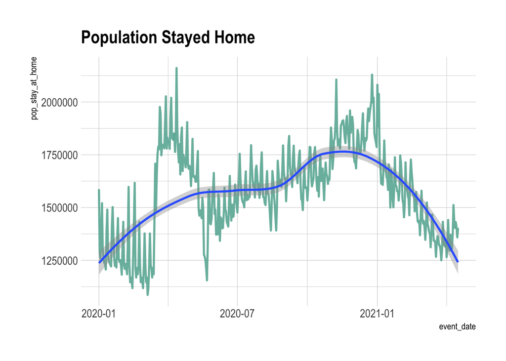

```r
ggplot(data=BTS_transportation_data_by_date, aes(x=event_date, y=pop_stay_at_home)) +
  geom_line(color="#69b3a2", size=1, alpha=0.9)+
  geom_smooth(se=TRUE)+
  theme_ipsum() +
  ggtitle("Population Stayed Home")
```

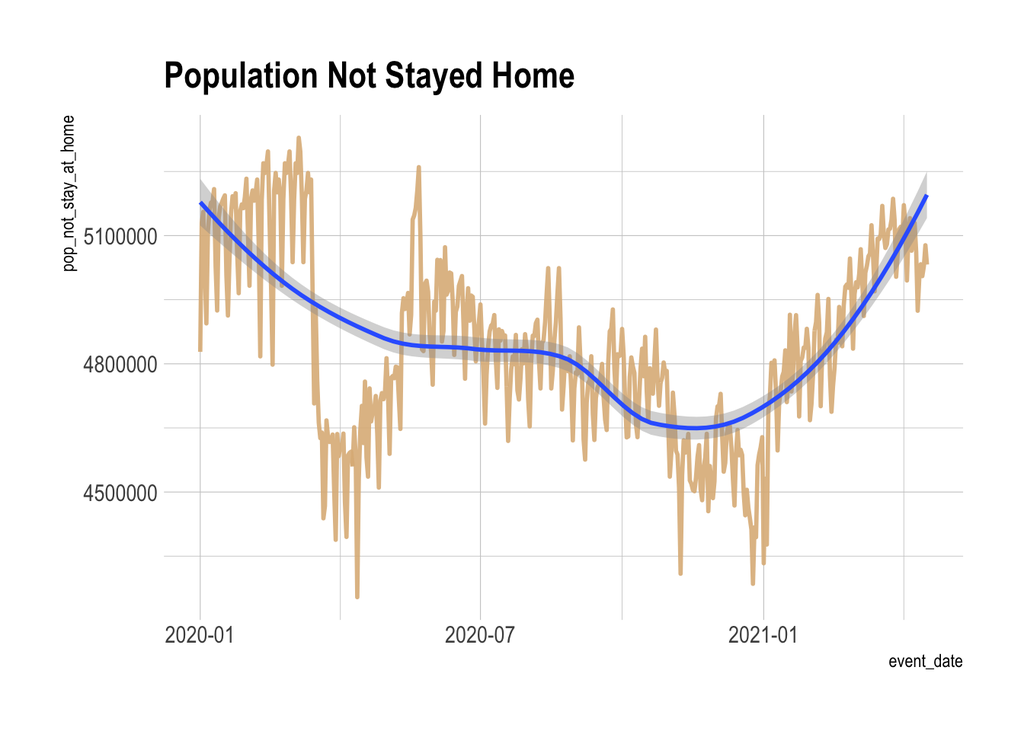

```r
ggplot(data=BTS_transportation_data_by_date, aes(x=event_date, y=pop_not_stay_at_home)) +
  geom_line(color="#DEB887", size=1, alpha=0.9)+
  geom_smooth(se=TRUE)+
  theme_ipsum() +
  ggtitle("Population Not Stayed Home")
```

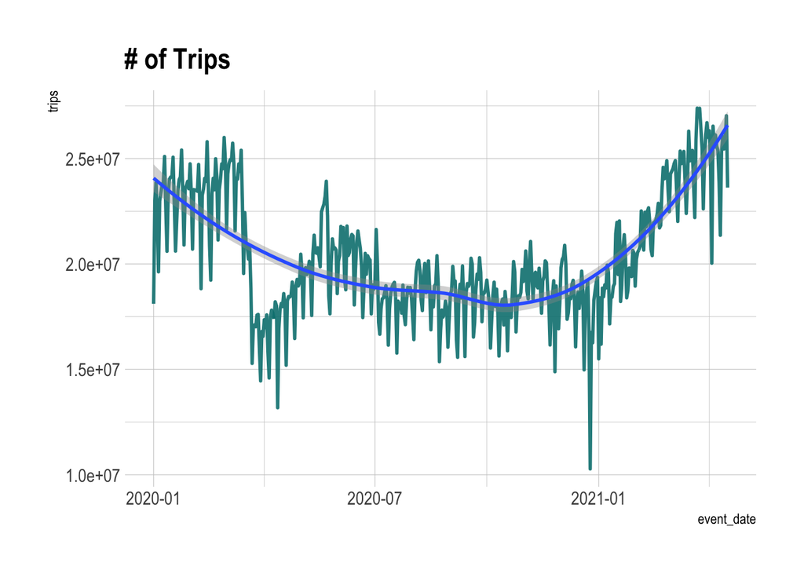

```r
ggplot(data=BTS_transportation_data_by_date, aes(x=event_date, y=trips)) +
 geom_line(color="#008080", size=1, alpha=0.9)+
  geom_smooth(se=TRUE)+
  theme_ipsum() +
  ggtitle("# of Trips")
```

#### Govt Poilyc and Transits

- Normalized the data to streamline the scale

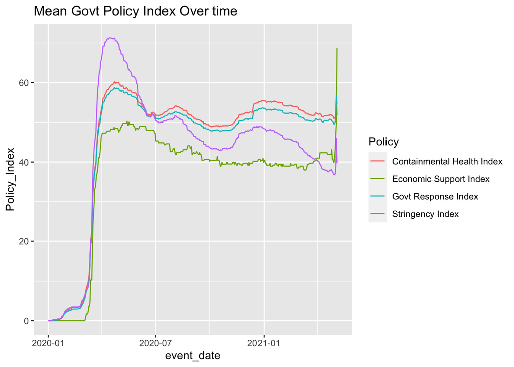

```r
govt_tracker_data_long <- govt_tracker_data_filter %>%
  group_by(event_date) %>%
  summarise("Economic Support Index"= mean(EconomicSupportIndex, na.rm=TRUE),
            "Containmental Health Index"= mean(ContainmentHealthIndex, na.rm=TRUE),
            "Govt Response Index"= mean(GovernmentResponseIndex ,na.rm=TRUE),
            "Stringency Index"=mean(StringencyIndex ,na.rm=TRUE)) %>%
    pivot_longer(cols = 2:ncol(.),names_to = "Policy", values_to = "Policy_Index")

ggplot(data=govt_tracker_data_long, aes(x=event_date, y=Policy_Index,color = Policy)) +
 geom_line()+
  ggtitle("Mean Govt Policy Index Over time")
```

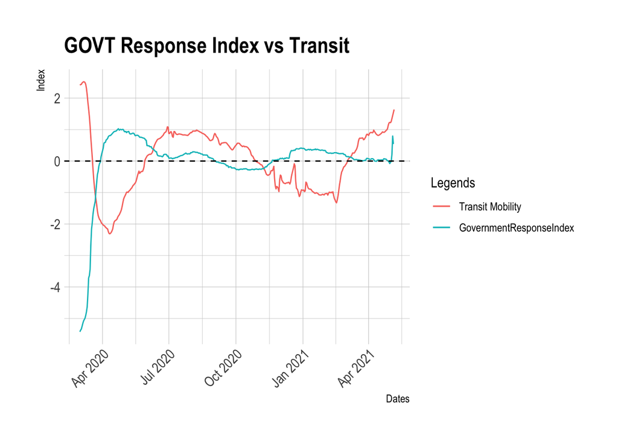

```r
govt_norm <- govt_policy_mobility_bts %>%
  remove_rownames %>%
  column_to_rownames(var="event_date")

govt_norm_data <- scale(govt_norm)

govt_policy_transit_df <-tibble::rownames_to_column(as.data.frame(govt_norm_data), "event_date") %>%
  mutate(event_date= as.Date(event_date, format = "%Y-%m-%d"))

ggplot(govt_policy_transit_df, aes(x=event_date)) +
  geom_line(aes(y= transit,color = "a"))+
  theme_ipsum() +
  labs(x = 'Dates',y='Index')+
  ggtitle("GOVT Response Index vs Transit")+
  geom_line(aes(y = GovernmentResponseIndex, color="c")) +
  theme(axis.text.x = element_text(angle = 45, hjust = 1))+
  geom_hline(yintercept=0,linetype="dashed")+
  scale_color_discrete(name = "Legends", labels = c("Transit Mobility", "GovernmentResponseIndex"))
```

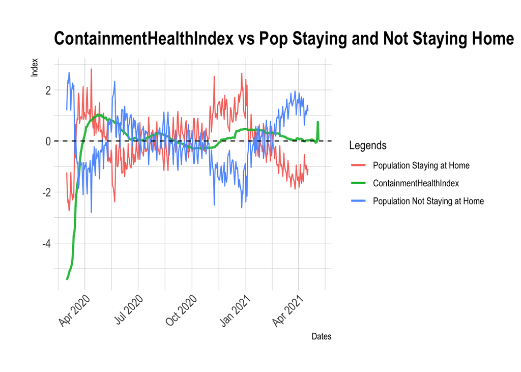

```r
ggplot(govt_policy_transit_df, aes(x=event_date)) +
  geom_line(aes(y= pop_stay_at_home,color = "a"))+
  theme_ipsum() +
  labs(x = 'Dates',y='Index')+
  ggtitle("ContainmentHealthIndex vs Pop Staying and Not Staying Home")+
  geom_line(aes(y = ContainmentHealthIndex,color="b"), size=1, alpha=0.9) +
  geom_line(aes(y= pop_not_stay_at_home,color = "c"))+
  theme(axis.text.x = element_text(angle = 45, hjust = 1))+
  geom_hline(yintercept=0,linetype="dashed")+
  scale_color_discrete(name = "Legends", labels = c("Population Staying at Home", "ContainmentHealthIndex", "Population Not Staying at Home"))
```

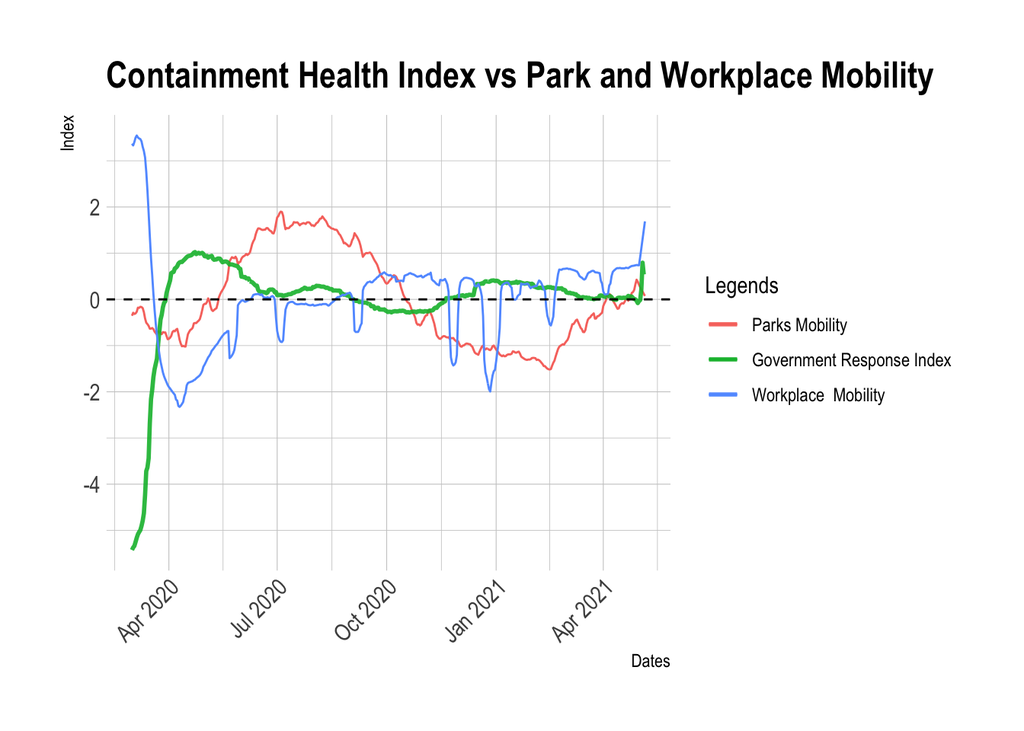

```
* Clearly Govt Policies and Containment Health actions had a major impact on workplaces and Transit, with lockdowns and other restrictions, people stayed home more and usage of Transit was significantly down.
* Interestly, people preferred to go to Park and Recreation. Mainly due to low threat of virus to get spread outdoors
```

```r
ggplot(govt_policy_transit_df, aes(x=event_date)) +
  geom_line(aes(y= parks,color = "a"))+
  theme_ipsum() +
  labs(x = 'Dates',y='Index')+
  ggtitle("Containment Health Index vs Park and Workplace Mobility")+
  geom_line(aes(y = GovernmentResponseIndex,color="b"), size=1, alpha=0.9) +
  geom_line(aes(y= workplace,color = "c"))+
  theme(axis.text.x = element_text(angle = 45, hjust = 1))+
  geom_hline(yintercept=0,linetype="dashed")+
  scale_color_discrete(name = "Legends", labels = c("Parks Mobility", "Government Response Index", "Workplace  Mobility"))
```

```r
##Top 5 States with Covid cases(Mean) overall (This is to take the vector and do the mobility analysis)
topcovid_data_mobility <- joined_mobility%>%
  group_by(Province_State) %>%
  summarise(cases=mean(actuals.cases,na.rm = TRUE)) %>%
  arrange(desc(cases)) %>%
  head(6) %>%
  select (Province_State)

mobility_data_top_5 <- joined_mobility %>%
  filter(Province_State %in% topcovid_data_mobility$Province_State)
```

#### Trend from Google Data for Top States by cases

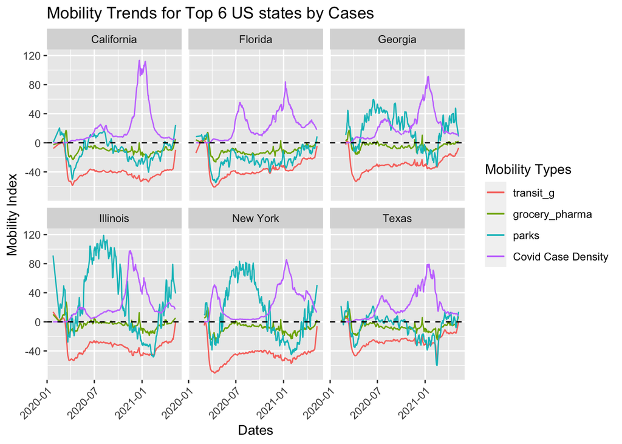

```r
ggplot(mobility_data_top_5, aes(x=event_date)) +
  geom_line(aes(y= transit_g,color = "a"))+ facet_wrap(~ Province_State) +
  labs(x = 'Dates',y='Mobility Index')+
  ggtitle("Mobility Trends for Top 6 US states by Cases")+
  geom_line(aes(y = grocery_pharma, color="c")) +
  geom_line(aes(y = parks, color="d")) +
  geom_line(aes(y = metrics.caseDensity, color="e")) +
  theme(axis.text.x = element_text(angle = 45, hjust = 1))+
  geom_hline(yintercept=0,linetype="dashed")+
  scale_color_discrete(name = "Mobility Types", labels = c("transit_g", "grocery_pharma","parks","Covid Case Density"))
```

- It is clearly visible that people’s usage of Transportation and Transit have declined over the course of time and now in 2021, it has started to pick up.
- When pandemic was at early stages and there were many restrictions, people have shown positive trend towards Parks and Outdoors. Clearly New York and Illinios saw some decline during cold weather.
- Grocery and Pharmaceutical did not see much decline as they were essential commodities.

#### Trend from Google Data for Top States by cases (Cont.)

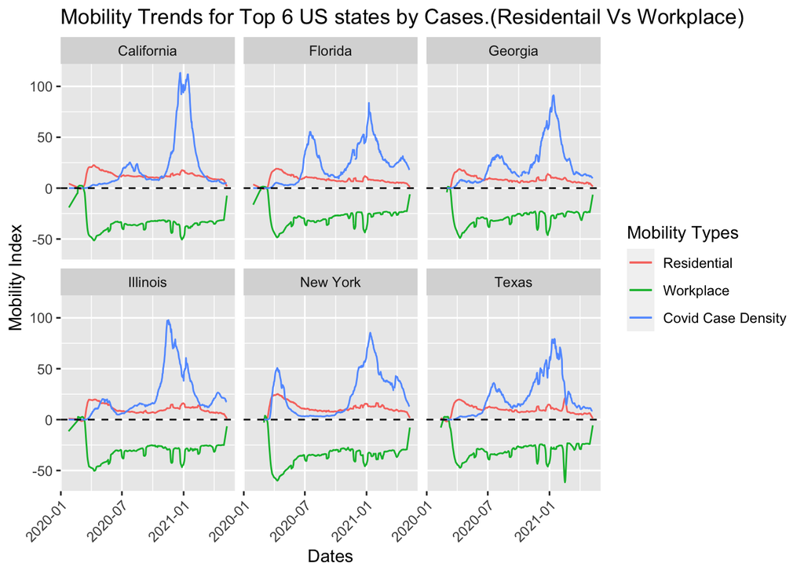

```r
ggplot(mobility_data_top_5, aes(x=event_date)) +
  geom_line(aes(y= residential,color = "a"))+ facet_wrap(~ Province_State) +
  labs(x = 'Dates',y='Mobility Index')+
  ggtitle("Mobility Trends for Top 6 US states by Cases.(Residentail Vs Workplace)")+
  geom_line(aes(y = workplace, color="c")) +
  geom_line(aes(y = metrics.caseDensity, color="e")) +
  theme(axis.text.x = element_text(angle = 45, hjust = 1))+
  geom_hline(yintercept=0,linetype="dashed")+
  scale_color_discrete(name = "Mobility Types", labels = c("Residential", "Workplace","Covid Case Density"))
```

- Workplace commute has significantly took at hit as most of the offices and businesses were closed and people have explored work from home option, However it has started to get picked up lately as cases are going down.
- Residential mobility was consistent throughout.

#### Trend from Apple Data for Top States by cases

[figure not shown]

```r
ggplot(mobility_data_top_5, aes(x=event_date)) +
  geom_line(aes(y= transit,color = "a"))+ facet_wrap(~ Province_State) +
   labs(x = 'Dates',y='Transportaion mode change')+
  ggtitle("Tranportation Mode Trends")+
  geom_line(aes(y = walking, color="g")) +
  geom_line(aes(y = driving, color="d")) +
  geom_line(aes(y = metrics.caseDensity, color="e")) +
  theme(axis.text.x = element_text(angle = 45, hjust = 1))+
  geom_hline(yintercept=0,linetype="dashed")+
  scale_color_discrete(name = "Transporation Mode", labels = c("Public Transport", "Walk","Driving","Covid Case Density"))
```

- Undoubtedly, Apple data has shown the changing habit in Transportation mode as well
- People drove and walked a lot as compared to baseline

#### Proportion of Movements and Case Density on Maps

[figure not shown]

```r
prepare_joined_mobility <- joined_mobility %>%
  filter(event_date>='2020-03-15') %>%
  mutate(rowCol=paste(event_date,"#",Province_State)) %>%
 select(rowCol,metrics.caseDensity, Staying.at.Home,Not.Staying.at.Home,actuals.deaths ,metrics.infectionRate,workplace,
        retail_recreation,parks,transit_g)

joined_mobility_normalized <- prepare_joined_mobility %>%
  remove_rownames %>%
  column_to_rownames(var="rowCol") %>%
  scale(.)

cholor_mobility_df <- tibble::rownames_to_column(as.data.frame(joined_mobility_normalized), "rowCol") %>%
  separate(rowCol, c("event_date", "Province_State"),"#") %>%
  mutate_all(trimws) %>%
  mutate(event_date=as.Date(event_date)) %>%
  mutate_at(vars(Staying.at.Home,Not.Staying.at.Home, metrics.caseDensity), as.numeric)

cholro_stay_home <- function(df,x,y){
  df %>%
  filter(event_date >= x & event_date <= y) %>%
  group_by(Province_State) %>%
  summarise(value = mean(Staying.at.Home, na.rm=TRUE)) %>%
  mutate(region = tolower(Province_State)) %>%
  select (region, value)
}

covid_data_mobility_first_6_i <- cholro_stay_home(cholor_mobility_df,"2020-03-01","2020-09-01")
covid_data_mobility_next_6_i <- cholro_stay_home(cholor_mobility_df,"2020-09-01","2021-04-01")

cholro_not_stay_home <- function(df,x,y){
  df %>%
  filter(event_date >= x & event_date <= y) %>%
  group_by(Province_State) %>%
  summarise(value = mean(Not.Staying.at.Home, na.rm=TRUE)) %>%
  mutate(region = tolower(Province_State)) %>%
  select (region, value)
}

covid_data_mobility_first_6_o <- cholro_not_stay_home(cholor_mobility_df,"2020-03-01","2020-09-01")
covid_data_mobility_next_6_o <- cholro_not_stay_home(cholor_mobility_df,"2020-09-01","2021-04-01")

cholro_cases <- function(df,x,y){
  df %>%
  filter(event_date >= x & event_date <= y) %>%
  group_by(Province_State) %>%
   summarise(value = mean(metrics.caseDensity, na.rm=TRUE)) %>%
  mutate(region = tolower(Province_State)) %>%
  select (region, value)
}

covid_data_cases_first_6_c <- cholro_cases(cholor_mobility_df,"2020-03-01","2020-09-01")
covid_data_cases_next_6_c <- cholro_cases(cholor_mobility_df,"2020-09-01","2021-04-01")
## ChoropletMaps preparation
c = StateChoropleth$new(covid_data_mobility_first_6_i)
c$title = "Mar20-Oct20 At Home"
c$set_num_colors(7)
c$set_zoom(NULL)
c$show_labels = FALSE
IndooorMobility2020 = c$render()

c = StateChoropleth$new(covid_data_mobility_next_6_i)
c$title = "Oct20-Apr21 At Home"
c$set_num_colors(7)
c$set_zoom(NULL)
c$show_labels = FALSE
IndooorMobility2021 = c$render()

c = StateChoropleth$new(covid_data_mobility_first_6_o)
c$title = "Mar20-Oct20 At Home"
c$set_num_colors(7)
c$set_zoom(NULL)
c$show_labels = FALSE
OutdoorMobiility2020 = c$render()

c = StateChoropleth$new(covid_data_mobility_next_6_o)
c$title = "Oct20-Apr21 At Home"
c$set_num_colors(7)
c$set_zoom(NULL)
c$show_labels = FALSE
OutdoorMobiility2021 = c$render()

c = StateChoropleth$new(covid_data_cases_first_6_c)
c$title = "Mar20-Oct20 Case Density"
c$set_num_colors(7)
c$set_zoom(NULL)
c$show_labels = FALSE
Covid2020 = c$render()

c = StateChoropleth$new(covid_data_cases_next_6_c)
c$title = "Oct20-Apr21 Case Density"
c$set_num_colors(7)
c$set_zoom(NULL)
c$show_labels = FALSE
Covid2021 = c$render()

library(gridExtra)
grid.arrange(IndooorMobility2020, IndooorMobility2021,OutdoorMobiility2020,OutdoorMobiility2021,Covid2020,Covid2021)
```

#### Overall US Mobility against Case Density

- Summarized the data by month and normalized the scale to get the consistency in scale

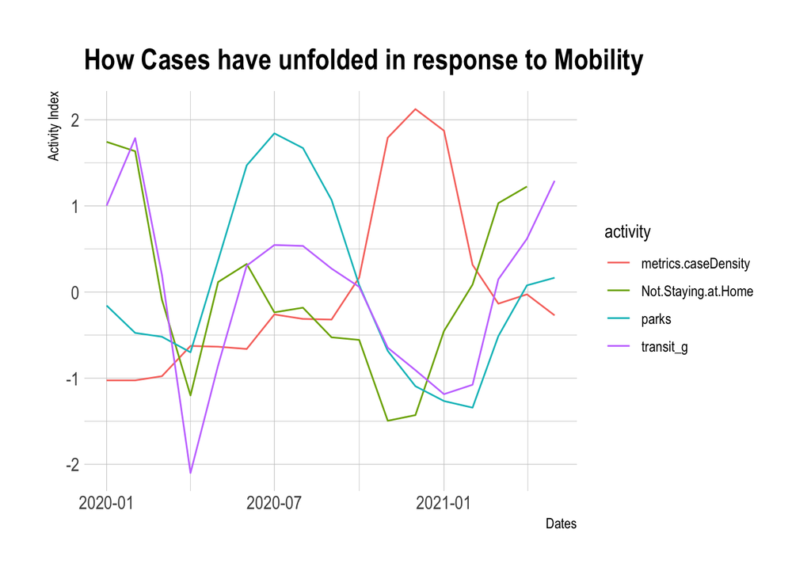

```r
joined_mobility_us <- joined_mobility %>%
  group_by(month = lubridate::floor_date(event_date, "month")) %>%
   summarise(metrics.caseDensity=mean(metrics.caseDensity,na.rm = TRUE),
             parks=mean(parks,na.rm = TRUE),
             transit_g=mean(transit_g,na.rm = TRUE),
             Not.Staying.at.Home=mean(Not.Staying.at.Home,na.rm = TRUE)
             )

covid_norm <- joined_mobility_us %>%
  remove_rownames %>%
  column_to_rownames(var="month")

covid_norm_data <- scale(covid_norm)

df <-tibble::rownames_to_column(as.data.frame(covid_norm_data), "event_date") %>%
  pivot_longer(cols = 2:ncol(.),names_to = "activity", values_to = "activity_index") %>%
  mutate(event_date= as.Date(event_date, format = "%Y-%m-%d"))

ggplot(df,aes(x=event_date,y = activity_index,color=activity))+
  geom_line()+  ggtitle("How Cases have unfolded in response to Mobility")+  labs(x = "Dates",y="Activity Index")+
  theme_ipsum()
```

### Conclusion

We all know that Covid has impacted all wakes of life from all the visualization and post data wrangling, it is much evident that communities have tweaked behavior during peak of COVID times, people refrained from using public transport, preferred more outdoor activities. Workplace mobility was decreased significantly as well. Interestingly residential mobility remained consistent which might be an attribution that people mostly traveled between residential address and grocery or parks. There was not much dip in grocery and pharma which is understandable as demand remained consistent except initial days of COVID. Additionally States policies have widely impacted the mobility, Govt lockdowns and other policy action were clearly had an impact. From apple transportation data, people preferred driving which is unusual for cities with mass transit.